# MEDB 5501, Module 13

2025-11-18

## Topics to be covered, 1

- What you will learn
  - The two by two crosstabulaton
  - Test of equality of two proportions
  - R code for the test of equality of two proportions
  - Sample size calculations
  - R code for sample size calculations

## Topics to be covered, 2

- What you will learn
  - Chi-squared test of independence
  - R code for the chi-squared test of independence
  - Odds ratios and relative risks
  - R code for odds ratios and relative risks
  - Your homework

## The crosstabulation of two binary variables

```
            Variable2
             0   1
Variable1 0 n00 n01
          1 n10 n11
```

## Example: Titanic data

- Crosstabulation

```
        survived
sex      yes  no
  female 308 154
  male   142 709
```

## Multiple ways to display, 1

- Crosstabulation

```
        survived
sex      yes  no
  female 308 154
  male   142 709
```

- Swap rows

```
        survived
sex      yes  no
  male   142 709
  female 308 154
```

- Swap columns

```
        survived
sex       no yes
  female 154 308
  male   709 142
```

- Swab both

```
        survived
sex       no yes
  male   709 142
  female 154 308
```

## Multiple ways to display, 2

- Transposed

```
        sex
survived female male
     yes    308  142
     no     154  709
```

- Transposed, swap rows

```
        sex
survived female male
     no     154  709
     yes    308  142
```

- Transposed, swap columns

```
        sex
survived male female
     yes  142    308
     no   709    154
```

- Transposed, swap both

```
        sex
survived male female
     no   709    154
     yes  142    308
```

## Row and column percents

- Crosstabulation with row totals

```
        survived
sex      yes  no Sum
  female 308 154 462
  male   142 709 851
```

- Row percents

```
        survived
sex            yes        no       Sum
  female 0.6666667 0.3333333 1.0000000
  male   0.1668625 0.8331375 1.0000000
```

- Cross tabulation with column totals

```
        survived
sex      yes  no
  female 308 154
  male   142 709
  Sum    450 863
```

- Column percents

```
        survived
sex            yes        no
  female 0.6844444 0.1784473
  male   0.3155556 0.8215527
  Sum    1.0000000 1.0000000
```

## Cell percents

- Cell totals

```
        survived
sex       yes   no  Sum
  female  308  154  462
  male    142  709  851
  Sum     450  863 1313
```

- Cell percents

```
        survived
sex            yes        no       Sum
  female 0.2345773 0.1172887 0.3518660
  male   0.1081493 0.5399848 0.6481340
  Sum    0.3427266 0.6572734 1.0000000
```

## My recommendation

- Outcome variable is the columns
- Intervention/exposure variable is the rows
- Calculate row percentages

```
        survived
sex            yes        no
  female 0.6666667 0.3333333
  male   0.1668625 0.8331375
```

## Always round, 1

```
  0.6666667
- 0.1668625
  ---------
  ?????????
```

## Always round, 2

```
  0.67
- 0.17
  ----
  ????
```

## Break #1

- What you have learned
  - The two by two crosstabulaton
- What’s coming next
  - Test of equality of two proportions

## The binomial distribution

- You have n trials of an “experiment”
- Two outcomes, “success” or “failure”
- $\pi$ is probability of success
- Each trial is independent

## Example, creating a family of three children, 1

- You have 3 trials (pregnancies)
- Two outcomes, girl (success) or boy (failure)
- $\pi$ = 0.5 is probability of success
- Each child is independent

## Example, creating a family of three children, 2

- Eight possible outcomes
  - X=0, BBB
  - X=1, BBG, BGB, GBB
  - X=2, BGG, GBG, GGB
  - X=3, GGG

## Example, creating a family of three children, 3

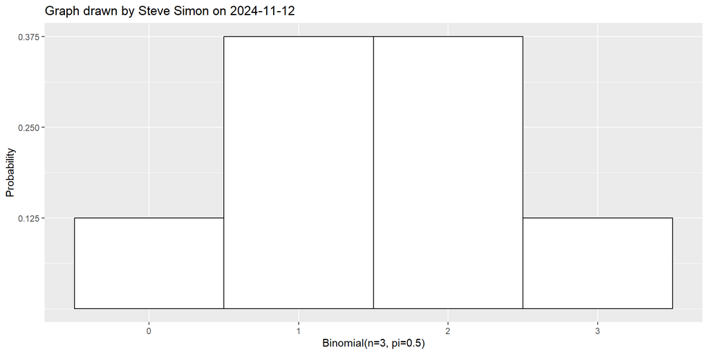

## Example, Binomial(n=10, pi=0.2)

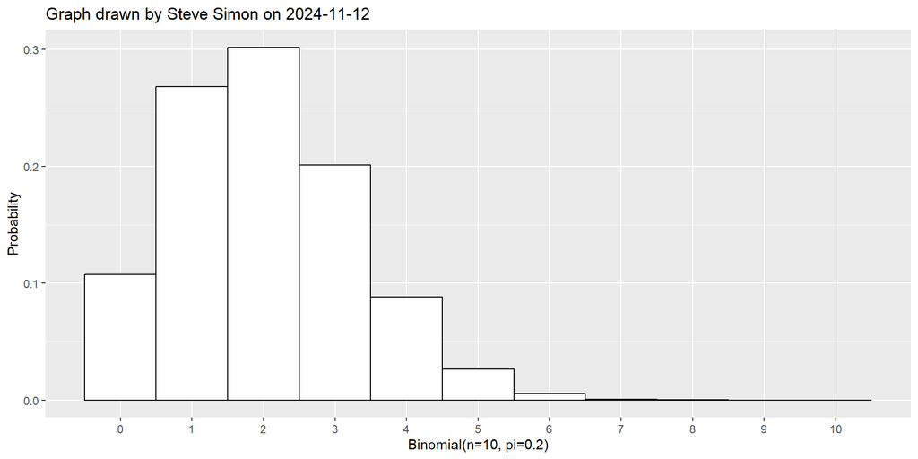

## Example, Binomial(n=20, pi=0.75)

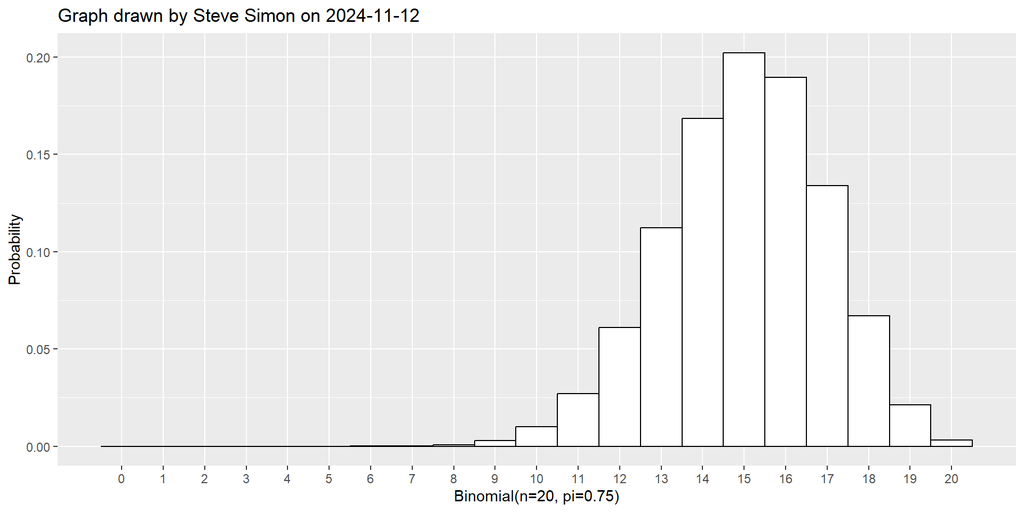

## Two proportions model, 1

- Scenario 1
  - $X_1$ is a random binomial($n_1, \pi_1$)
  - $X_2$ is a random binomial($n_2, \pi_2$)
  - $X_1$ and $X_2$ are independent

## Two proportions model, 2

- Scenario 2
  - Sample $X_{11}, X_{12}, ..., X_{1n_1}$
  - Sample $X_{21}, X_{22}, ..., X_{2n_2}$
  - Only possible values are 0, 1
  - $P[X_{1i}=1]=\pi_1$, $P[X_{2i}=1]=\pi_2$

## Two proportions model, 3

- $H_0:\ \pi_1 - \pi_2 = 0$
- $H_1:\ \pi_1 - \pi_2 \ne 0$

## Two proportions model, 4

- $T = \frac{p_1-p_2}{se}$
  - $se=\sqrt{\bar{p}(1-\bar{p})(\frac{1}{n_1}+\frac{1}{n_2})}$
  - $\bar{p}=\frac{n_1p_1+n_2p_2}{n_1+n_2}$
- Accept $H_0$ if T is close to zero.
  - If $Z(\alpha/2) < T < Z(1-\alpha/2)$

## Two proportions model, 5

- p-value = $2P[Z >|T|]$
- Accept $H_0$ if p-value > $\alpha$

## Some variations of the test statistic, 1

- Yates continuity correction
  - $T = \frac{p_1-p_2 + c}{se}$
  - Formula for c is messy
  - Net effect is to pull T closer to zero
  - Better to meet the normal approximation

## Some variations of the test statistic, 2

- Chi-squared test
  - $T = \Big(\frac{p_1-p_2}{se}\Big)^2$
  - Accept $H_0$ if T < $\chi^2(1-\alpha, df=1)$
  - p-value = $P[\chi^2(df=1) > T]$
  - Does not allow for easy test of one-sided hypothesis
- Chi-squared test with Yates continuity correction
  - $T = \Big(\frac{p_1-p_2 + c}{se}\Big)^2$

## One-sided test, 1

- $H_0:\ \pi_1 - \pi_2 = 0$
- $H_1:\ \pi_1 - \pi_2 > 0$
  - Accept $H_0$ if T < $z(1-\alpha)$
  - p-value = $P[Z > T]$
  - Accept $H_0$ if p-value > $\alpha$

## One-sided test, 2

- $H_0:\ \pi_1 - \pi_2 = 0$
- $H_1:\ \pi_1 - \pi_2 < 0$
  - Accept $H_0$ if T > $z(\alpha)$
  - p-value = $P[Z < T]$
  - Accept $H_0$ if p-value > $\alpha$

## Two sample test of proportions with Titanic data, 1

```
        survived
sex      yes  no
  female 308 154
  male   142 709
```

## Two sample test of proportions with Titanic data, 2

```
        survived
sex            yes        no
  female 0.6666667 0.3333333
  male   0.1668625 0.8331375
```

## Two sample test of proportions with Titanic data, 3

```
    2-sample test for equality of proportions without continuity correction

data:  table1
X-squared = 332.06, df = 1, p-value < 2.2e-16
alternative hypothesis: two.sided
95 percent confidence interval:
 0.4500519 0.5495564
sample estimates:
   prop 1    prop 2
0.6666667 0.1668625
```

## Break #2

- What you have learned
  - Test of equality of two proportions
- What’s coming next
  - R code for the test of equality of two proportions

## R code for the test of two proportions

Please refer to the program simon-5501-13-titanic.qmd

## Break #3

- What you have learned
  - R code for the test of equality of two proportions
- What’s coming next
  - Sample size calculations

## What you need for a continuous outcome

- Research hypothesis
- Standard deviation of your outcome measure
- Minimum clinically important difference
- Other details
  - Type I error rate (usually 0.05)
  - Power (usually 0.90)

## What you need for a categorical outcome

- Research hypothesis
- Expected proportion in the control group
- Minimum clinically important difference

## Hypothetical scenario, 1

- Weight loss study
  - Control is recommended diet and exercise routine
  - Treatment adds experimental weight loss drug
  - Binary event, losing at least 5 pounds after 6 months
- Hypothesis proportion is higher in treatment group than control
- Proportion in control group is 10%
- Need to see at least 5% more events in treatment group

## Hypothetical scenario, 2

- Set power to 90%
- Set Type I error rate (alpha) to 5%

```r
power.prop.test(
    p1=0.10,
    p2=0.15,
    power=0.9,
    sig.level=0.05)
```

```
     Two-sample comparison of proportions power calculation

              n = 917.3206
             p1 = 0.1
             p2 = 0.15
      sig.level = 0.05
          power = 0.9
    alternative = two.sided

NOTE: n is number in *each* group
```

## Rule of 50

- Want to detect a doubling or halving
- Need 25 to 50 events in each group
- Example
  - Control probability is 0.1
  - Want to see 20% in treatment group
  - 25/0.1 = 250; 50/0.1 = 500

## Break #4

- What you have learned
  - Sample size calculations
- What’s coming next
  - R code for sample size calculations

## R code for the sample size calculations

Please refer to the program simon-5501-13-titanic.qmd.

## Break #5

- What you have learned
  - R code for sample size calculations
- What’s coming next
  - Chi-squared test of independence

## Crosstabulation with row and column totals

- Counts

```
        survived
sex       yes   no  Sum
  female  308  154  462
  male    142  709  851
  Sum     450  863 1313
```

- Cell percents

```
        survived
sex            yes        no       Sum
  female 0.2345773 0.1172887 0.3518660
  male   0.1081493 0.5399848 0.6481340
  Sum    0.3427266 0.6572734 1.0000000
```

## Conditional probability

- $P[A|B] = \frac{P[A \cap B]}{P[B]}$
  - Read $P[A|B]$ as probability of A given B
  - Read $P[A \cap B]$ as probability of A and B
  - Note: $P[A|B] \ne P[B|A]$

## What does independence mean?

- $P[A|B] = P[A]$
- Equivalent definition of independence
  - $P[A \cap B] = P[A] \times P[B]$

## Positive association

- $P[A|B] > P[A]$
- $P[A \cap B] > P[A] \times P[B]$
  - Change direction for negative association

## Expected counts

```
             Good      Bad
            Outcome  Outcome     Total
Placebo        ?        ?       (a+b)/n
Treated        ?        ?       (c+d)/n
Total       (a+c)/n  (b+d)/n       1

where n=a+b+c+d
```

- $E_{11}=n\times\frac{a+b}{n}\times\frac{a+c}{n}$
  - $E_{12},\ E_{21},\ E_{22}$ are defined similarly

## Expected counts for Titanic data

```
        survived
sex            yes        no       Sum
  female                     0.3518660
  male                       0.6481340
  Sum    0.3427266 0.6572734 1.0000000
```

- $E_{11}$ = 1313 $\times$ 0.3518660 $\times$ 0.3427266 = 158.3397091
- $E_{12}$ = 303.6603489
- $E_{21}$ = 291.6603167
- $E_{22}$ = 559.3396253

## Expected counts for Titanic data

- Observed counts

```
        survived
sex      yes  no
  female 308 154
  male   142 709
```

- Expected counts

```
        survived
sex           yes       no
  female 158.3397 303.6603
  male   291.6603 559.3397
```

## Test statistic

- $H_0:\ Independence$
- $H_1:\ Dependence$
  - $T=\Sigma_i \Sigma_j \frac{(O_{ij}-E_{ij})^2}{E_{ij}}$
  - p-value = $P[T > \chi^2(df=1)]$
    - Accept $H_0$ if T < $\chi^2(1-\alpha, df=1)$
    - Accept $H_0$ if p-value > $\alpha$

## Example with Titanic data

- $H_0:$ Mortality is independent of sex
- $H_1:$ Mortality is related to sex

```r
m1 <- chisq.test(table1, correct=FALSE)
m1
```

```
    Pearson's Chi-squared test

data:  table1
X-squared = 332.06, df = 1, p-value < 2.2e-16
```

## Chi-squared test is an approximation

- Reasonable if all expected counts > 5
- Use Fisher’s Exact test otherwise

## Fisher’s exact test for the Titanic data

```r
m2 <- fisher.test(table1)
m2
```

```
    Fisher's Exact Test for Count Data

data:  table1
p-value < 2.2e-16
alternative hypothesis: true odds ratio is not equal to 1
95 percent confidence interval:
  7.601263 13.122462
sample estimates:
odds ratio
  9.965185
```

## Break #6

- What you have learned
  - Chi-squared test of independence
- What’s coming next
  - R code for the chi-squared test of independence

## R code for the Chi-squared test of independence

Please refer to the program simon-5501-13-titanic.qmd.

## Break #7

- What you have learned
  - R code for the chi-squared test of independence
- What’s coming next
  - Odds ratios and relative risks

## The crosstabulation of two binary variables, 1

```
             Good      Bad
            Outcome  Outcome
Placebo        a        b
Treated        c        d
```

- a, number of placebo patients with good outcome
- b, number of placebo patients with bad outcome
- c, number of treated patients with good outcome
- d, number of treated patients with bad outcome

## The crosstabulation of two binary variables, 2

- Note: rows could be
  - Exposed/Unexposed
  - Female/Male
  - Old/Young
  - Many other possibilities

## Example: Titanic data

- Crosstabulation

```
        survived
sex      yes  no
  female 308 154
  male   142 709
```

## Odds ratio

```
             Good      Bad
            Outcome  Outcome  Odds
Placebo        a        b     b/a
Treated        c        d     d/c
```

- Odds ratio = $\frac{d/c}{b/a} = \frac{ad}{bc}$

## Relative risk (Risk ratio)

```
             Good      Bad
            Outcome  Outcome  Probabililty
Placebo        a        b     b/(a+b)
Treated        c        d     d/(c+d)
```

## Using odds

- Three to one in favor of victory
  - Expect three wins for every loss
- Four to one odds against victory
  - Expect four losses for every win
- Odds = Prob / (1- Prob)
- Prob = Odds / (Odds + 1)

## Ambiguity in odds

- “In favor” versus “Against”
- “Good” outcome versus “Bad” outcome
- Get clues from the context
  - Example: chances of winning the lottery (million to one)
    - One million winners for every loser?
    - One million losers for every winner?

## Example of odds and probability

[figure not shown]

Odds for winning election to U.S. president in 2024

- Biden: $\frac{8/13}{1 + 8/13} = \frac{8}{21} = 0.381$
- Trump: $\frac{1/3}{1 + 1/3} = \frac{1}{4} = 0.25$
- DeSantis: $\frac{1/16}{1+1/16} = \frac{1}{17} = 0.059$

## Probability of winning 2022 World Cup

```
Brazil: 30.8%
Argentina: 18.2%
France: 16.7%
Spain: 13.3%
England: `10%
Portugal: 7.7%
Netherlands: 5.3%
Croatia: 2.8%
```

Argentina: $\frac{0.182}{1-0.182} = 0.2225 \approx 2/9$

France: $\frac{0.167}{1-0.167} = 0.2004 \approx 1/5$

```
Switzerland: 1.5%
Japan: 1.5%
Morocco: 1.2%
USA: 1.1%
Senegal: 1%
South Korea: 0.67%
Poland: 0.55%
Australia: 0.5%
```

## Odds against winning 2022 football World Cup

```
Brazil: 9 to 4
Argentina: 9 to 2
France: 5 to 1
Spain: 13 to 2
England: 9 to 1
Portugal: 12 to 1
Netherlands: 18 to 1
Croatia: 35 to 1
```

```
Switzerland: 65 to 1
Japan: 65 to 1
Morocco: 80 to 1
USA: 90 to 1
Senegal: 100 to 1
South Korea: 150 to 1
Poland: 180 to 1
Australia: 200 to 1
```

## Odd ratio for Titanic data

```
        survived
sex       yes   no  odds
  female  308  154  154/308 = 0.5
  male    142  709  709/142 = 4.993 (round to 5.0)

Odds ratio = 5.0 / 0.5 = 10

        survived
sex       yes   no  odds
  male    142  709  709/142 = 4.993 (round to 5.0)
  female  308  154  154/308 = 0.5

Odds ratio = 0.5 / 5.0 = 0.1
```

## Relative risk for Titanic data, 1

```
        survived
sex       yes   no  total probability
  female  308  154  462   154/462 = 0.3333
  male    142  709  851   709/851 = 0.8331

Relative risk = 0.8331 / 0.3333 = 2.500

        survived
sex       yes   no  total probability
  male    142  709  851   709/851 = 0.8331
  female  308  154  462   154/462 = 0.3333

Relative risk = 0.3333 / 0.8331 = 0.4
```

## Relative risk for Titanic data, 2

```
        survived
sex       no   yes  total probability
  female  154  308  462   308/462 = 0.6667
  male    709  142  851   142/851 = 0.1669

Relative risk = 0.1669 / 0.6667 = 0.25

        survived
sex       no   yes  total probability
  male    709  142  851   142/851 = 0.1669
  female  154  308  462   308/462 = 0.6667

Relative risk = 0.6667 / 0.1669 = 4.0
```

## Break #8

- What you have learned
  - Odds ratios and relative risks
- What’s coming next
  - R code for odds ratios and relative risks

## R code for odds ratios and relative risks

Please refer to the program simon-5501-13-titanic.qmd.

## Break #9

- What you have learned
  - R code for odds ratios and relative risks
- What’s coming next
  - Your homework

## Your homework

Please refer to the file [simon-5501-13-directions.qmd](https://github.com/pmean/classes/blob/master/biostats-1/13/src/simon-5501-13-directions.md).

## Summary, 1

- What you have learned
  - The two by two crosstabulaton
  - Test of equality of two proportions
  - R code for the test of equality of two proportions
  - Sample size calculations
  - R code for sample size calculations

## Summary, 2

- What you have learned
  - Chi-squared test of independence
  - R code for the chi-squared test of independence
  - Odds ratios and relative risks
  - R code for odds ratios and relative risks
  - Your homework